# Bayesmsm: An R package for longitunal causal analysis using Bayesian Marginal Structural Models

Observational studies offer a viable, efficient, and low-cost design to readily gather evidence on exposure effects. Although more practical, exposure mechanism is nonrandomized and causal inference methods are required to draw causal conclusions. Popular approaches used in health research are predominantly frequentist methods. Bayesian approaches have unique estimation features that are useful in many settings, however, there is a general lack of open-access software packages to carry out these analyses. Our project seeks to address this gap by developing a user-friendly R package named “bayesmsm” for the implementation of the Bayesian Marginal Structural Models for longitudinal data with continuous or binary outcome.

Xiao Yan https://github.com/XiaoYan-Clarence (Dalla Lana School of Public Health, University of Toronto) , Kuan Liu https://www.kuan-liu.com/ (Dalla Lana School of Public Health, University of Toronto)  
2024-07-02

## 2 Longitudinal causal framework and Bayesian Marginal Structural Models (BMSMs)

### 2.1 Notation

In this section, we introduce the notation for the Bayesian Marginal Structural Models (BMSMs). Let $n$ be the total number of subjects enrolled in the study, indexed by $i = 1, \ldots, n$. Each subject is observed over $J$ visits, indexed by $j = 1, \ldots, J$. For each subject $i$ at visit $j$, let $Y_{i}$ denote the final outcome, $X_{ij}$ the covariates, and $Z_{ij}$ the treatment. The full histories of these variables up to visit $j$ for subject $i$ are represented as $Y_{i}$, $\bar{X}_{ij} = \{X_{i1}, \ldots, X_{ij}\}$, and $\bar{Z}_{ij} = \{Z_{i1}, \ldots, Z_{ij}\}$, respectively. At each visit $j$, $X_{ij}$ is measured first, and $Z_{ij}$ is decided and recorded afterward (Liu 2021).

In the case of right-censoring, we introduce the censoring indicator $C_{ij}$, where $C_{ij} = 1$ if the subject $i$ is censored at visit $j$ and $C_{ij} = 0$ if not censored. The full history of the censoring indicators up to visit $j$ is denoted as $\bar{C}_{ij} = \{C_{i1}, \ldots, C_{ij}\}$. The observed data for each subject $i$ at visit $j$ is thus represented by $\bar{V}_{ij} = Y_{i}, \bar{X}_{ij}, \bar{Z}_{ij-1}, \bar{C}_{ij}\}$.

### 2.2 Causal structure

Under the observational setting, the treatment decision at each visit $j$ is made based on covariates $X_{ij}$ and the past treatment assignment history $\bar{Z}_{ij-1}$. We assume that the final outcome $Y_{i}$ is influenced by the entire history of covariates and treatment assignments.

The hypothesized causal structure for two consecutive visits and a follow-up response is represented in a directed acyclic graph (DAG) in the next section. This structure assumes that there is no competition for treatment resources between subjects at each visit, meaning that the treatment assignment for one subject does not affect the outcome of another subject. Furthermore, we assume that there are no unmeasured confounders with respect to the outcome and the treatment at any given visit. This assumption is often referred to as the sequential ignorability of treatment assignment, which implies that given the observed history up to visit $j$, the treatment assignment $Z_{ij}$ is independent of the potential outcomes (Liu et al. 2020).

### 2.3 Directed Acyclic Graph (DAG)

[interactive chart not shown]

Figure 1: Example DAG for 2 visits

Figure 1 shows the causal structure for two consecutive visits with a final outcome , which is the Directed Acyclic Graph (DAG) between treatment assignment, covariates and the final outcome. A causal graph is a directed acyclic graph in which the vertices (nodes) of the graph represent variables and the directed edges (arrows) represent direct causal effects (Robins et al. 2000). Here, $X_{ij-1}$ is the baseline covariate. The covariates $X_{ij-1}$, $X_{ij}$ and time-varying covariate $Z_{ij-1}$ potentially influence treatment assignments $Z_{ij}$, and ultimately, the outcome $Y_{i}$. Each treatment decision $Z_j$ at visit $j$ is determined at the end of that visit, based on all previous information. This DAG also assumes that there is no unmeasured confounding.

### 2.4 Data-generating mechanism causal framework

We construct a data-generating mechanism for a non-repeatedly measured outcome $Y_{i}$. Under the data-generating mechanism, causal inference with observational data can simply be viewed as a prediction problem (Liu et al. 2020). This framework allows us to conceptualize the problem as drawing inference from an ideal population, where treatment assignment is unconfounded (similar to a randomized setting), and comparing it to the data observed in a confounded observational setting (Dawid et al. 2010; Røysland et al. 2011; Arjas 2012; Saarela et al. 2015; Hernán and Robins 2016). The experimental data generating mechanism is indexed by $\mathcal{E}$, which generates samples from the ideal population where treatment assignment at each visit is independent of the covariates given past treatment assignments, i.e., $Z_{ij} \perp X_{ij} \mid Z_{ij-1}$; the observational data generating mechanism is indexed by $\mathcal{O}$, which generates samples from the observed population where independence does not hold and treatment assignment $Z_{ij}$ at visit $j$ depends on $\{X_{ij}, Z_{ij-1}\}$ (Liu et al. 2020).

Under such data-generating mechanism, we have two important assumptions. The first assumption has already been stated above, which is $Z_{ij} \perp X_{ij} \mid Z_{ij-1}$. The second positivity assumption states that at each visit, any treatment sequence that is compatible with the complete treatment history has a non-zero probability of occuring, i.e. $0 < P(Z_{ij} | X_{ij}, Z_{ij-1}) < 1$ for $j = 1, \ldots, J$.

Under $\mathcal{E}$, we can specify the marginal outcome model as (Liu 2021):

$g_y( E_{\mathcal{E}}[{y}_{i} \mid \bar{z}_{iJ}]) = {\Theta} \ \sum_{j=1}^J z_{ij}, \quad j=1,\ldots,J.$

We draw inference from an ideal population ($\mathcal{E}$) but with observed data subject to confounding ($\mathcal{O}$). Here, ${\Theta}$ is known as the marginal treatment effect. For example, if we have a binary time-varying treatment, ${\Theta}$ is interpreted as the expected change in the final outcome $Y_i$ relative to a one-unit increase in the cumulative treatment exposure prior to visit $j$.

### 2.5 Bayesian Marginal Structural Models with Right-Censoring

The BMSM approach involves calculating the stabilized weights, which are the product of the inverse probability of treatment weights (IPTW) and the inverse probability of censoring weights (IPCW). In the case of right-censoring and conditionally independent censoring based on observed history, subject-visit-specific IPCW weights can be calculated and integrated with IPTW weights when applying conventional MSMs (Robins et al. 2000; Hernán and Robins 2016). The IPCW weights can be used within two Bayesian methods: the Bayesian MSMs and the two-step BPSA, under the data-generating mechanism causal framework (Saarela et al. 2015).

#### IPTW and IPCW Weights

The traditional IPTW subject-visit-specific stabilized weights are calculated as the product of the probabilities of the observed treatment history under the experimental setting to that under the observational setting. Mathematically, the IPTW for subject $i$ at visit $j$ is given by:

$$\phi_{ij}^{(s)} = \prod_{l=1}^{j} \frac{e_{il}^{(s)}(\tilde{z}_{il-1}, \tilde{c}_{il-1} = 0, \alpha_l^{(s)}; E)}{e_{il}^{(s)}(\tilde{z}_{il-1}, \tilde{x}_{il}, \tilde{y}_{i}, \tilde{c}_{il-1} = 0, \beta_l^{(s)}; O)}, \quad j = 1, \ldots, t_i$$

where $e_{il}^{(s)}$ denotes the propensity score for the $s$-th posterior sample of the treatment model parameters $\alpha$ and $\beta$.

In addition to the IPTW, IPCW are derived to account for censoring. These weights are calculated using the probabilities of the censoring history under the experimental and observational settings. The IPCW for the $s$-th posterior sample are given by:

$$\psi_{ij}^{(s)} = \prod_{l=1}^{j} \frac{P(c_{il}^{(s)} = 0 \mid \tilde{z}_{il-1}, \tilde{c}_{il-1} = 0, \zeta_l^{(s)}; E)}{P(c_{il}^{(s)} = 0 \mid \tilde{z}_{il-1}, \tilde{x}_{il}, \tilde{y}_{i}, \tilde{c}_{il-1} = 0, \eta_l^{(s)}; O)}, \quad j = 1, \ldots, t_i$$

where $P(c_{il}^{(s)} = 0)$ represents the probability of not being censored at visit $l$ for the $s$-th posterior sample of the censoring model parameters $\zeta$ and $\eta$.

#### Combined Weights and Marginal Treatment Effect Estimation

To account for both treatment assignment and censoring biases, the combined stabilized weights for subject $i$ at visit $j$ are given by:

$$\Phi_{ij}^{(s)} = \phi_{ij}^{(s)} \times \psi_{ij}^{(s)}, \quad j = 1, \ldots, t_i$$

#### Two-step Bayesian PSA

The marginal response model for non-repeated measures is given by:

$$g_y( E_{\mathcal{E}}[{Y}_{i} \mid \bar{Z}_{ij}]) = {\theta_0 + \theta_1} \
\sum_{l=1}^j z_{il}, \quad l=1,\ldots,j.$$

To estimate the treatment effect $\theta_1$, we maximize the expected utility function:

$$\mathbb{E}[U(\theta; v_{ij})] = \int \Phi_{ij} \log P(\tilde{y}_{i} \mid \tilde{z}_{ij}, \theta) P_n(v_{ij}) dv_{ij}$$

where $v_{ij} = \{\tilde{y}_{i}, \tilde{z}_{ij}, \tilde{x}_{ij}\}$ represents the observed data and $P_n(v_{ij})$ is the non-parametric Bayesian bootstrap estimate.

The estimation of BMSMs with right-censoring follows these steps:

1. **Estimate treatment weights $w_{ij}$** using posterior samples of the parameters $\alpha$ and $\beta$ by fitting a series of logistic regressions in a Bayesian framework.
2. **Estimate $P_n(v_{ij})$** using the non-parametric Bayesian bootstrap with $Dirichlet(1,\ldots,1)$ sampling weights (Liu et al. 2020).

## 3 Description of `bayesmsm`

The `bayesmsm` package is developed to implement Bayesian Marginal Structural Models (BMSMs). It contains three core functions: `bayesweight`, `bayesweight_cen`, and `bayesmsm`. `bayesweight` estimates treatment weights using posterior samples of $\alpha$ and $\beta$ via running MCMC with JAGS based on the treatment model input, whereas `bayesweight_cen` extends the function `bayesweight` to handle right-censored data. `bayesmsm` then uses the estimated treatment weights to perform Bayesian non-parametric bootstrap to estimate causal effects. In this section, we describe these functions and their usage in detail.

### 3.1 Input Dataset Structure

The `bayesmsm` package requires the input dataset to be in wide format. Each row of the data frame corresponds to a single patient treatment record. The dataset must include the following columns: the outcome variable, which can be binary or continuous (`outcome`), the treatment variable at each time point (`treatment`), the covariate variables at each time point (`covariates`), and the censoring indicator at each time point (`censoring`) if there is right-censoring.

#### Specifying the Outcome Type

The `bayesmsm` package allows for binary or continuous outcomes. The outcome type should be specified in the `family` argument when calling the `bayesmsm` function. For binary outcomes, the package fits a data-specific weighted log-likelihood of a binomial distribution, while for continuous outcomes, it fits a data-specific weighted log-likelihood of a normal distribution.

### 3.2 Core Functions

#### Bayesian Treatment Effect Weight Estimation Using `bayesweight`

```r
weights <- bayesweight(trtmodel.list = list(a_1 ~ w1 + w2 + L1_1 + L2_1,
                                            a_2 ~ w1 + w2 + L1_1 + L2_1 + L1_2 + L2_2 + a_1),
                       data = testdata,
                       n.iter = 25000,
                       n.burnin = 15000,
                       n.thin = 5,
                       n.chains = 2,
                       seed = 890123,
                       parallel = TRUE)
```

The `bayesweight` function is used to estimate the inverse probability of treatment weights (IPTW). This function works by automatically running MCMC with JAGS based on the treatment model input provided through `trtmodel.list`, and it also saves a JAGS model file in the working directory so that the user can check to review the model specifications.

The function `bayesweight` accepts several arguments including `trtmodel.list`, which is a list of formulas corresponding to each time point with the time-specific treatment variable on the left hand side and pre-treatment covariates to be balanced on the right hand side. Interactions and functions of covariates are allowed. The `data` argument specifies the dataset containing all the variables specified in `trtmodel.list`. The `n.iter`, `n.burnin`, `n.thin`, and `n.chains` arguments control the MCMC simulation parameters, including the total number of iterations, the number of burn-in iterations, the thinning rate, and the number of MCMC chains to run. The `seed` argument ensures reproducibility, and the `parallel` argument indicates whether to run the MCMC chains in parallel. Non-parallel computing requires that `n.chains = 1`. Parallel MCMC requires at least 2 chains because computing is running on 1 core per chain, and we recommend using at most 2 chains less than the number of available cores on the user’s computer.

#### Handling Right-Censoring with `bayesweight_cen`

```r
weights <- bayesweight_cen(trtmodel.list = list(A1 ~ L11 + L21,
                                                A2 ~ L11 + L21 + L12 + L22 + A1,
                                                A3 ~ L11 + L21 + L12 + L22 + A1 + L13 + L23 + A2),
                           cenmodel.list = list(C1 ~ L11 + L21,
                                                C2 ~ L11 + L21 + A1,
                                                C3 ~ L11 + L21 + A1 + L12 + L22 + A2),
                           data = simdat_cen,
                           n.iter = 25000,
                           n.burnin = 15000,
                           n.thin = 5,
                           n.chains = 2,
                           seed = 890123,
                           parallel = TRUE)
```

The `bayesweight_cen` function extends the `bayesweight` function by incorporating inverse probability of censoring weights (IPCW) to handle right-censoring. The arguments are similar to `bayesweight`, with an additional `cenmodel.list` argument for the censoring model. The censoring indicators should take covariates and treatments before that visit in order to indicate at or after which time point the observations were censored.

The function `bayesweight_cen` accepts the following arguments: `trtmodel.list`, which is a list of formulas corresponding to each time point. The `cenmodel.list` is a list of formulas for the censoring model, where the censoring indicators take covariates and treatments before that visit. The `data` argument specifies the dataset containing all the variables specified in `trtmodel.list` and `cenmodel.list`. Similarly, the `n.iter`, `n.burnin`, `n.thin`, and `n.chains` arguments specify the MCMC simulation parameters, including the total number of iterations, the number of burn-in iterations, the thinning rate, and the number of MCMC chains to run. The `seed` argument ensures reproducibility, and the `parallel` argument indicates whether to run the MCMC chains in parallel.

The function returns a list of the updated weights by multiplying subject-specific treatment assignment weights by subject-specific censoring weights (Liu 2021).

#### Bayesian Non-Parametric Bootstrap Using `bayesmsm`

```r
model <- bayesmsm(ymodel = y ~ a_1+a_2,
                  nvisit = 2,
                  reference = c(rep(0,2)),
                  comparator = c(rep(1,2)),
                  family = "gaussian", # or "binomial"
                  data = testdata,
                  wmean = weights,
                  nboot = 1000,
                  optim_method = "BFGS",
                  seed = 890123,
                  parallel = TRUE,
                  ncore = 6)
```

The `bayesmsm` function uses the weights estimated by `bayesweight` or `bayesweight_cen` to fit the Bayesian Marginal Structural Model and estimate the marginal treatment effects. This function performs Bayesian non-parametric bootstrap to maximize the utility function with respect to the causal effect in order to estimate the causal parameters.

The function `bayesmsm` accepts several arguments including `ymodel`, which is a formula of the outcome model that can include interactions and functions of covariates. The `nvisit` argument specifies the number of visits or time points considered in the model. The `reference` and `comparator` arguments specify the baseline or reference intervention and the comparison intervention across all visits, respectively. The `family` argument specifies the outcome distribution family; “gaussian” for continuous outcomes or “binomial” for binary outcomes. The `data` argument specifies the dataset containing all variables specified previously. The `wmean` argument is a vector of treatment assignment weights. The `nboot` argument specifies the number of bootstrap iterations to perform, and the `optim_method` argument specifies the optimization method used to find the best parameters in the model. The `seed` argument ensures reproducibility, and the `parallel` and `ncore` arguments indicate whether to run with parallelization and the number of cores to use for parallel computation.

The function returns a model object which contains the following: - For binary outcomes: the mean, standard deviation, and 95% credible interval of the Risk Difference (RD), Risk Ratio (RR), and Odds Ratio (OR). It also includes a data frame containing the bootstrap samples for the reference effect, comparator effect, RD, RR, and OR, as well as the reference and comparator levels chosen by the user. - For continuous outcomes: the mean, standard deviation, and 95% credible interval of the Risk Difference (RD). It also includes a data frame containing the bootstrap samples for the reference effect, comparator effect, and RD, as well as the reference and comparator levels chosen by the user.

## 4 Numerical Examples and Implementation Using Simulated Dataset

In this section, we illustrate the implementation of the `bayesmsm` package using a simulated dataset. We present an example with a non-censored dataset and a continuous outcome to demonstrate the functions `bayesweight` and `bayesmsm`. This example will provide a comprehensive understanding of how to apply the package to real-world data.

### 4.1 Example 1: Simulated Non-Censored Dataset with Continuous Outcome

#### Dataset Introduction

In our simulation study, we use a longitudinal dataset designed and simulated to mimic complex real-world clinical data. This dataset consists of 1,000 patients observed over 3 visits, 2 of which patients were assigned a treatment. The end-of-study outcome $Y$ is continuous, which is the variable of interest. The dataset includes baseline covariates $w_1$ and $w_2$, where $w_1$ is binary (0 for female, 1 for male) and $w_2$ is continuous with a mean of 12.048. Time-dependent covariates $L_1$ and $L_2$ are also included, with $L_1$ being binary and $L_2$ continuous. They reflect variables that might change with time during the study period. The binary treatment variables are denoted as $a_1$ and $a_2$ for visits 1 and 2. The treatment variables equaling 0 represents not receiving treatment at that time point, and 1 represents receiving treatment. There is no missing data in the dataset.

Figure 2 shows the Directed Acyclic Graph (DAG) of this simulated dataset, with an overview:

[interactive chart not shown]

Figure 2: Example DAG for non-censored simulated dataset

| w1 | w2 | L1_1 | L2_1 | a_1 | L1_2 | L2_2 | a_2 | y |
| --- | --- | --- | --- | --- | --- | --- | --- | --- |
| 0 | 9.592428616059934 | 0 | -0.4156794360289815 | 0 | 1 | -0.123205373308362 | 0 | 0.9773711545806334 |
| 1 | 8.025205635605143 | 1 | 0.3271899354836821 | 0 | 0 | 1.047555180506998 | 0 | 0.5193337934770335 |
| 0 | 16.10714022429962 | 0 | -0.3805177693787017 | 0 | 0 | 0.451557820766288 | 1 | -0.8161817197462765 |
| 1 | 15.00424521042529 | 0 | 1.379270099147326 | 0 | 1 | 0.2351547861193508 | 0 | 3.606631509010199 |
| 1 | 5.963333850685196 | 0 | 0.2437692136130012 | 0 | 0 | -1.732707030669677 | 0 | -0.1648255548418869 |
| 0 | 11.61941019660285 | 0 | -0.4990742141304494 | 0 | 1 | 1.822445952206404 | 0 | 3.545485590765318 |
| 1 | 8.416208708974004 | 1 | -1.712730876995588 | 0 | 0 | -1.407178859994681 | 1 | 1.705565029577714 |
| 1 | 3.716995717832145 | 0 | -0.5965111487177179 | 1 | 0 | -0.3936989313545899 | 1 | -2.095068126972874 |
| 1 | 12.60048052475257 | 1 | 2.182023657380342 | 1 | 0 | 0.9050599443297667 | 0 | 1.057052370264873 |
| 0 | 11.68315316296565 | 1 | -0.4439308895014084 | 0 | 0 | 0.8054504839383311 | 0 | 3.168142940840214 |

[output cut: 990 more lines]

#### Frequency Counts by Treatment Combinations

```
#>
#>       0   1
#>   0 520 201
#>   1 111 168
```

- Suppose the causal parameter of interest is the average treatment effect between always treated and never treated,

$ATE = E(Y \mid Z_1 = 1, Z_2 = 1) - E(Y \mid Z_1 = 0, Z_2 = 0)$

#### Usage of functions on the simulated dataset

Next, we use the `bayesweight` function to estimate the inverse probability of treatment weights (IPTW). We specify the treatment model for each time point, including the relevant covariates.

```r
weights <- bayesweight(trtmodel.list = list(a_1 ~ w1 + w2 + L1_1 + L2_1,
                                            a_2 ~ w1 + w2 + L1_1 + L2_1 + L1_2 + L2_2 + a_1),
                        data = testdata,
                        n.iter = 25000,
                        n.burnin = 15000,
                        n.thin = 5,
                        n.chains = 1,
                        seed = 890123,
                        parallel = FALSE)
str(weights)
```

```
#>  num [1:1000] 1.246 1.142 1.004 0.82 0.809 ...
```

Using the weights estimated by `bayesweight`, we now use Bayesian non-parametric bootstrap to maximize the utility function with respect to the causal effect using the `bayesmsm` function. We specify the model and other relevant parameters as follows.

```r
model <- bayesmsm(ymodel = y ~ a_1+a_2,
                  nvisit = 2,
                  reference = c(rep(0,2)),
                  comparator = c(rep(1,2)),
                  family = "gaussian",
                  data = testdata,
                  wmean = weights,
                  nboot = 1000,
                  optim_method = "BFGS",
                  parallel = TRUE,
                  seed = 890123,
                  ncore = 2)
str(model)
```

```
#> List of 6
#>  $ RD_mean    : num -3.16
#>  $ RD_sd      : num 0.0949
#>  $ RD_quantile: Named num [1:2] -3.33 -2.98
#>   ..- attr(*, "names")= chr [1:2] "2.5%" "97.5%"
#>  $ bootdata   :'data.frame': 1000 obs. of  3 variables:
#>   ..$ effect_reference : num [1:1000] 2.36 2.28 2.26 2.33 2.31 ...
#>   ..$ effect_comparator: num [1:1000] -0.948 -0.824 -0.754 -0.796 -0.764 ...
#>   ..$ RD               : num [1:1000] -3.3 -3.1 -3.01 -3.12 -3.07 ...
#>  $ reference  : num [1:2] 0 0
#>  $ comparator : num [1:2] 1 1
```

#### Output

The `bayesmsm` function returns a model object containing the following:

For continuous outcomes: the mean, standard deviation, and 95% credible interval of the Risk Difference (RD). It also includes a data frame containing the bootstrap samples for the reference effect, comparator effect, and RD, as well as the reference and comparator levels chosen by the user. We can extract and visualize the results as follows:

```
#>   effect_reference effect_comparator        RD
#> 1         2.356735        -0.9475989 -3.304334
#> 2         2.279948        -0.8244967 -3.104444
#> 3         2.258172        -0.7544791 -3.012651
#> 4         2.328787        -0.7958156 -3.124602
#> 5         2.307883        -0.7643851 -3.072268
#> 6         2.299340        -0.8433683 -3.142708
```

This data frame in the model output allows users to plot and summarize the Bayesian posterior bootstrap results.

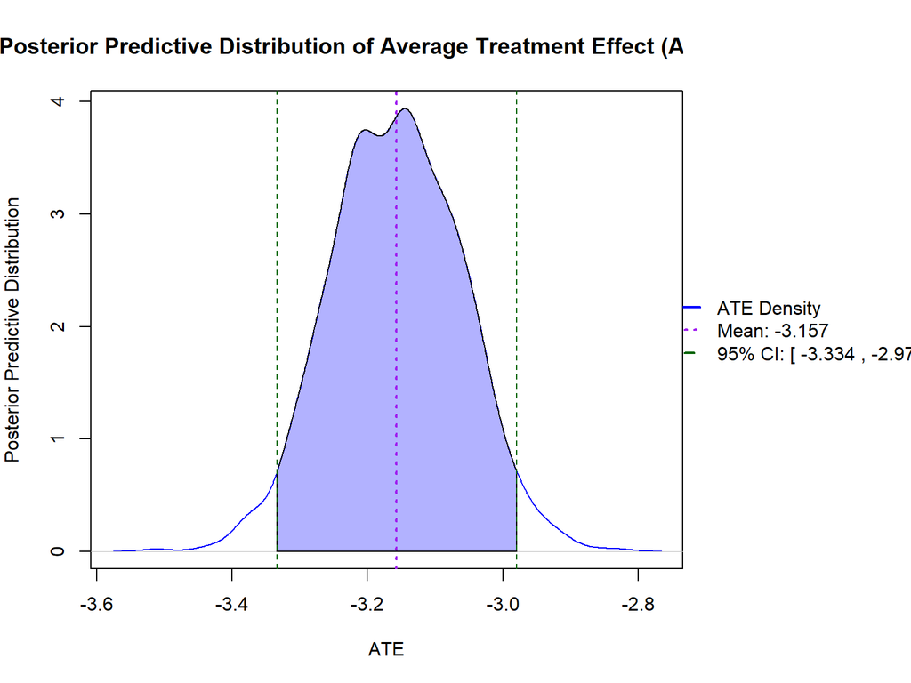

Figure 3: Visualization of results using `plot_ATE`

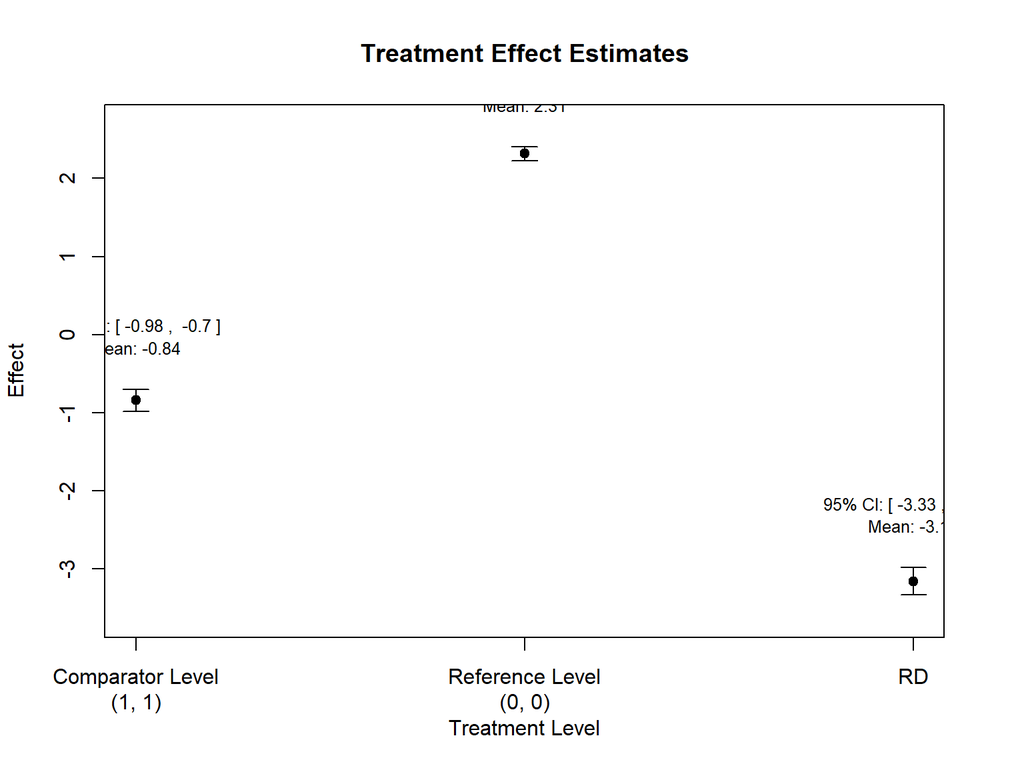

Figure 4: Visualization of results using `plot_est_box`

## 5 Discussion

### 5.2 CRAN Task Views implied by cited packages

E. Arjas. *Causal inference from observational data: A bayesian predictive approach.* Wiley Online Library, 2012. URL https://onlinelibrary.wiley.com/doi/abs/10.1002/9781119945710.ch7. accessed 1 August 2019.

A. Dawid, V. Didelez, et al. Identifying the consequences of dynamic treatment strategies: A decision-theoretic overview. *Statistical Surveys*, 4: 184–231, 2010.

M. Hernán and J. Robins. Using big data to emulate a target trial when a randomized trial is not available. *American Journal of Epidemiology*, 183(8): 758–764, 2016.

K. Liu. Bayesian causal inference with longitudinal data. 2021.

K. Liu et al. Estimation of causal effects with repeatedly measured outcomes in a bayesian framework. *Statistical Methods in Medical Research*, 2020.

J. Robins et al. Marginal structural models and causal inference in epidemiology. 2000.

K. Røysland et al. A martingale approach to continuous-time marginal structural models. *Bernoulli*, 17(3): 895–915, 2011.

O. Saarela et al. On bayesian estimation of marginal structural models. 2015.